# Network Analysis Homework: Hollywood Actors Graph

Aiden Dickson

2026-01-03

## I. Getting Ready

```r
set.seed(1111)
library(igraph)
library(ggraph)
library(corrplot)
```

## Task 1: Re-read the Graph from GitHub (Cloud)

```r
fileLink = 'https://github.com/AidenFlowers/assign2-computation-socsci-methods-dacss-690c/raw/main/homework-resources/hollywood.graphml'
actors = read_graph(fileLink, format = 'graphml')
head(actors)
```

```
## 6 x 11 sparse Matrix of class "dgCMatrix"
```

```
##
## Robin Williams    . . . . . 1 . 1 1 . .
## Tom Hardy         . . . 1 . . . . . . 1
## Dustin Hoffman    . . . 1 1 . . . . . 1
## Leonardo DiCaprio . 1 1 . 1 . . . . 1 .
## Tom Hanks         . . 1 1 . . . . 1 . .
## Al Pacino         1 . . . . . . 3 . . .
```

## Task 2: Compute Node Centrality Measures

```r
eigen = eigen_centrality(actors)$vector
close = closeness(actors, normalized = T)
betw = betweenness(actors, normalized = T)

DFCentrality = as.data.frame(cbind(eigen, close, betw), stringsAsFactors = F)
names(DFCentrality) = c('Eigenvector', 'Closeness', 'Betweenness')
DFCentrality$person = row.names(DFCentrality)

DFCentrality
```

```
##                   Eigenvector Closeness Betweenness            person
## Robin Williams    0.606705039 0.3571429  0.37777778    Robin Williams
## Tom Hardy         0.014699527 0.3703704  0.01111111         Tom Hardy
## Dustin Hoffman    0.034689773 0.4545455  0.17777778    Dustin Hoffman
## Leonardo DiCaprio 0.037143649 0.4761905  0.33333333 Leonardo DiCaprio
## Tom Hanks         0.072098921 0.5000000  0.53333333         Tom Hanks
## Al Pacino         1.000000000 0.2702703  0.00000000         Al Pacino
## Morgan Freeman    0.007860685 0.3125000  0.02222222    Morgan Freeman
## Robert De Niro    1.000000000 0.2702703  0.00000000    Robert De Niro
## Matt Damon        0.188206119 0.4347826  0.46666667        Matt Damon
## Jack Nicholson    0.012477963 0.3703704  0.07777778    Jack Nicholson
## Christian Bale    0.015873210 0.3846154  0.11111111    Christian Bale
```

## Task 3: Correlation Plot

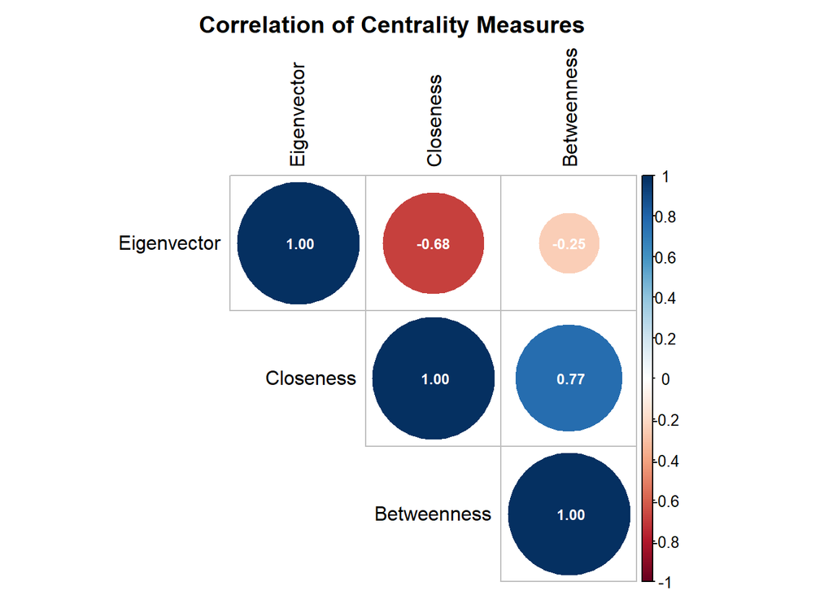

```r
cor_matrix = cor(DFCentrality[, c("Eigenvector", "Closeness", "Betweenness")])

corrplot(cor_matrix,
         method = "circle",
         type = "upper",
         addCoef.col = "white",
         number.cex = 0.75,
         tl.col = "black",
         title = "Correlation of Centrality Measures",
         mar = c(0, 0, 2, 2))
```

### Interpretation - Correlation of Centrality

- **Eigenvector vs Closeness (-0.68):** Strong negative correlation. Actors connected to other highly-connected actors form tight clusters but are distant from other groups.
- **Eigenvector vs Betweenness (-0.25):** Weak negative correlation. Being well-connected to important actors doesn’t strongly predict being a bridge between groups.
- **Closeness vs Betweenness (+0.77):** Strong positive correlation. Actors who can reach others quickly also tend to lie on shortest paths between others.

This pattern suggests a network with distinct clusters where some actors dominate one cluster while others serve as bridges.

## Task 4: Is it Possible Communities are Present?

```r
RandomNet = sample_gnp(length(V(actors)), p = edge_density(actors))
trans_actors = transitivity(actors)
trans_random = transitivity(RandomNet)
ratio = trans_actors / trans_random

cat("Actors transitivity:", trans_actors, "\n")
```

```
## Actors transitivity: 0.25
```

```r
cat("Random transitivity:", trans_random, "\n")
```

```
## Random transitivity: 0.2857143
```

```r
cat("Resultant Ratio:", sprintf("%.3f", ratio), "\n")
```

```
## Resultant Ratio: 0.875
```

### Interpretation - Possible Communities

- **Resultant Ratio** The resultant ratio is 0.875, which is less than 1. This means the Hollywood actors network has slightly less clustering than a comparable random network. Based on the transitivity test alone, there is no strong evidence for community structure. However, this test has limitations for small networks (11 nodes). *As we will see, the modularity scores from community detection algorithms (Girvan-Newman and Louvain, both > 0.4) provide stronger evidence that meaningful communities do exist.

## Task 5: Community Detection

### Girvan-Newman Algorithm

```r
partition_girvanNewman_best = cluster_edge_betweenness(actors)
gn_modularity = max(partition_girvanNewman_best$modularity)
cat("Girvan-Newman Modularity:", gn_modularity, "\n")
```

```
## Girvan-Newman Modularity: 0.4199219
```

### Louvain Algorithm

```r
partition_louvain_optimal = cluster_louvain(actors)
louvain_modularity = max(partition_louvain_optimal$modularity)
cat("Louvain Modularity:", louvain_modularity, "\n")
```

```
## Louvain Modularity: 0.4121094
```

### Plot the Best Result

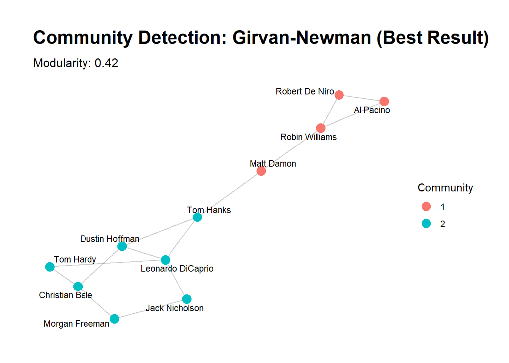

```r
V(actors)$louvain = as.factor(membership(partition_louvain_optimal))
V(actors)$girvanNewman = as.factor(membership(partition_girvanNewman_best))

best_algorithm = ifelse(gn_modularity > louvain_modularity, "Girvan-Newman", "Louvain")
best_partition = ifelse(gn_modularity > louvain_modularity, "girvanNewman", "louvain")
best_modularity = max(gn_modularity, louvain_modularity)

ggraph(graph = actors, layout = 'fr') +
  geom_edge_link(alpha = 0.2) +
  geom_node_point(aes(color = get(best_partition)), show.legend = TRUE, size = 4) +
  geom_node_text(aes(label = name), repel = TRUE, size = 3) +
  labs(title = paste("Community Detection:", best_algorithm, "(Best Result)"),
       subtitle = paste("Modularity:", round(best_modularity, 3)),
       color = "Community") +
  theme_graph()
```

### Interpretation - Girvan-Newman

The community detection reveals two distinct clusters in the Hollywood actors network. The modularity score above 0.4 indicates meaningful community structure. One cluster centres on actors like Al Pacino and Robert De Niro — who share high eigenvector centrality and multiple collaborations. The other cluster includes actors like Tom Hanks, who serves as a bridge between groups (high betweenness) rather than being deeply embedded in one cluster. This aligns with our earlier correlation findings: actors with high eigenvector centrality (connected to important others) tend to have low closeness (distant from the broader network), while bridge actors show the opposite pattern.